# Libraries

**MODE**

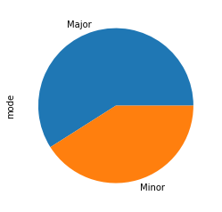

```python
data['mode'].apply(lambda x: 'Major' if x == 1 else 'Minor').value_counts().plot.pie()
```

**SPEECHINESS**

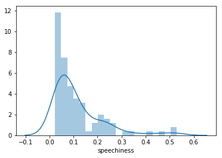

```python
sns.distplot(data['speechiness'], bins=20, kde=True)
```

In this graph we can see that most of the tracks are considered speechy from values lower than 0.2, but to make a better analysis we are going to divide these into 3 groups:

- Greater than 0.67 -- Highly Speechy
- between 0.33 and 0.67 -- Moderately Speechy
- Minor 0.33 -- Less Speechy

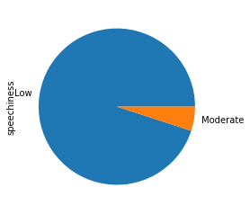

```python
pd.cut(data['speechiness'], bins=[0, 0.33, 0.67, 1], labels=['Low', 'Moderate', 'High']).value_counts().plot.pie()
```

Mostly the songs are less speechy ie more musical

```python
print('Most Speechy Songs')
data.sort_values('speechiness', ascending=False)[['name', 'speechiness']].head().reset_index(drop=True)
```

```
Most Speechy Songs
```

|  | name | speechiness |
| --- | --- | --- |
| 0 | Yes Indeed | 0.530 |
| 1 | River (feat. Ed Sheeran) | 0.516 |
| 2 | Youngblood | 0.463 |
| 3 | FEFE (feat. Nicki Minaj & Murda Beatz) | 0.412 |
| 4 | No Brainer | 0.342 |

```python
print('Least Speechy Songs')
data.sort_values('speechiness', ascending=True)[['name', 'speechiness']].head().reset_index(drop=True)
```

```
Least Speechy Songs
```

|  | name | speechiness |
| --- | --- | --- |
| 0 | Perfect | 0.0232 |
| 1 | Perfect Duet (Ed Sheeran & Beyonc?) | 0.0263 |
| 2 | changes | 0.0290 |
| 3 | Havana | 0.0300 |
| 4 | lovely (with Khalid) | 0.0333 |

```python
correlations('speechiness', ['key', 'mode'])
```

```
time_signature    0.235615
danceability      0.227075
tempo             0.102999
duration_ms      -0.009856
valence          -0.051054
Name: speechiness, dtype: float64
```

**ACOUSTICNESS**

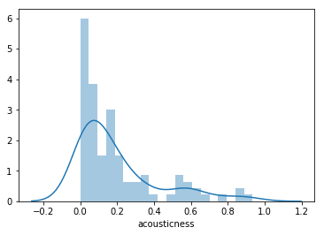

```python
sns.distplot(data['acousticness'], bins=20, kde=True)
```

In this graph we can see that most of the tracks are considered acoustic from values lower than 0.2, but to make a better analysis we are going to divide these into 3 groups:

- Greater than 0.5 -- Highly Acoustic
- between 0.25 and 0.5 -- Moderately Acoustic
- Minor 0.25 -- Less Acoustic

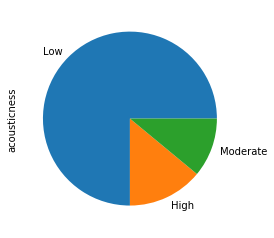

```python
pd.cut(data['acousticness'], bins=[0, 0.25, 0.5, 1], labels=['Low', 'Moderate', 'High']).value_counts().plot.pie()
```

```python
print('Most Acoustic Songs')
data.sort_values('acousticness', ascending=False)[['name', 'acousticness']].head().reset_index(drop=True)
```

```
Most Acoustic Songs
```

|  | name | acousticness |
| --- | --- | --- |
| 0 | lovely (with Khalid) | 0.934 |
| 1 | changes | 0.883 |
| 2 | Everybody Dies In Their Nightmares | 0.847 |
| 3 | Perfect Duet (Ed Sheeran & Beyonc?) | 0.779 |
| 4 | Be Alright | 0.697 |

```python
print('Least Acoustic Songs')
data.sort_values('acousticness', ascending=True)[['name', 'acousticness']].head().reset_index(drop=True)
```

```
Least Acoustic Songs
```

|  | name | acousticness |
| --- | --- | --- |
| 0 | HUMBLE. | 0.000282 |
| 1 | Look Alive (feat. Drake) | 0.001040 |
| 2 | New Rules | 0.002610 |
| 3 | XO TOUR Llif3 | 0.002640 |
| 4 | Stir Fry | 0.002990 |

```python
correlations('acousticness', ['key', 'mode'])
```

```
valence            -0.020800
duration_ms        -0.069627
speechiness        -0.081536
instrumentalness   -0.089583
danceability       -0.134374
Name: acousticness, dtype: float64
```

**INSTRUMENTALNESS**

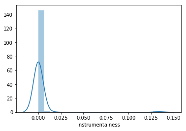

```python
sns.distplot(data['instrumentalness'], bins=20, kde=True)
```

In this graph we can see that most of the tracks are considered acoustic from values lower than 0.01, but to make a better analysis we are going to divide these into 3 groups:

- Greater than 0.05 -- Highly Instrumental
- between 0.005 and 0.05 -- Moderately Instrumental
- Minor 0.005 -- Less Instrumental

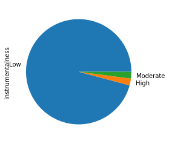

```python
pd.cut(data['instrumentalness'], bins=[0, 0.005, 0.05, 1], labels=['Low', 'Moderate', 'High']).value_counts().plot.pie()
```

```python
print('Most Instrumental Songs')
data.sort_values('instrumentalness', ascending=False)[['name', 'instrumentalness']].head().reset_index(drop=True)
```

```
Most Instrumental Songs
```

|  | name | instrumentalness |
| --- | --- | --- |
| 0 | Thunder | 0.13400 |
| 1 | Nonstop | 0.01300 |
| 2 | Moonlight | 0.00404 |
| 3 | SAD! | 0.00372 |
| 4 | X | 0.00108 |

```python
print(f"{len(data[data['instrumentalness'] == 0])} songs has 0 instrumentalness")
```

```
52 songs has 0 instrumentalness
```

```python
correlations('instrumentalness', ['key', 'mode'])
```

```
tempo             0.178142
energy            0.093684
loudness          0.036248
time_signature    0.011894
liveness         -0.016249
Name: instrumentalness, dtype: float64
```

**LIVENESS**

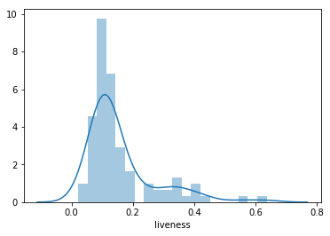

```python
sns.distplot(data['liveness'], bins=20, kde=True)
```

In this graph we can see that most of the tracks are considered liveness from values lower than 0.2, but to make a better analysis we are going to divide these into 3 groups:

- Greater than 0.8 -- Live
- between 0.2 and 0.8 -- Moderately Live
- Minor 0.2 -- Not Live

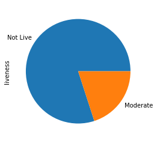

```python
pd.cut(data['liveness'], bins=[0, 0.2, 0.8, 1], labels=['Not Live', 'Moderate', 'Live']).value_counts().plot.pie()
```

> There are no live songs

```python
print('Songs with most liveness')
data.sort_values('liveness', ascending=False)[['name', 'liveness']].head().reset_index(drop=True)
```

```
Songs with most liveness
```

|  | name | liveness |
| --- | --- | --- |
| 0 | Me Niego | 0.636 |
| 1 | God's Plan | 0.552 |
| 2 | Mine | 0.451 |
| 3 | Nevermind | 0.418 |
| 4 | Dura | 0.409 |

```python
print('Songs with least liveness')
data.sort_values('liveness', ascending=True)[['name', 'liveness']].head().reset_index(drop=True)
```

```
Songs with least liveness
```

|  | name | liveness |
| --- | --- | --- |
| 0 | Finesse (Remix) [feat. Cardi B] | 0.0215 |
| 1 | This Is Me | 0.0424 |
| 2 | 1, 2, 3 (feat. Jason Derulo & De La Ghetto) | 0.0501 |
| 3 | Body (feat. brando) | 0.0543 |
| 4 | Jackie Chan | 0.0586 |

```python
correlations('liveness', ['key', 'mode'])
```

```
energy              0.050542
loudness            0.000006
instrumentalness   -0.016249
danceability       -0.038761
valence            -0.042612
Name: liveness, dtype: float64
```

**VALENCE**

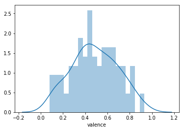

```python
sns.distplot(data['valence'], bins=20, kde=True)
```

To make a better analysis we are going to divide these into 3 groups:

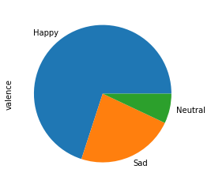

```python
pd.cut(data['valence'], bins=[0, 0.33, 0.36, 1], labels=['Sad', 'Neutral', 'Happy']).value_counts().plot.pie()
```

```python
print('Most Happy Songs')
data.sort_values('valence', ascending=False)[['name', 'valence']].head().reset_index(drop=True)
```

```
Most Happy Songs
```

|  | name | valence |
| --- | --- | --- |
| 0 | Shape of You | 0.931 |
| 1 | Finesse (Remix) [feat. Cardi B] | 0.926 |
| 2 | Bella | 0.844 |
| 3 | D?jala que vuelva (feat. Manuel Turizo) | 0.839 |
| 4 | Criminal | 0.839 |

```python
print('Most Sad Songs')
data.sort_values('valence', ascending=True)[['name', 'valence']].head().reset_index(drop=True)
```

```
Most Sad Songs
```

|  | name | valence |
| --- | --- | --- |
| 0 | Nevermind | 0.0796 |
| 1 | Dusk Till Dawn - Radio Edit | 0.0967 |
| 2 | This Is Me | 0.1000 |
| 3 | lovely (with Khalid) | 0.1200 |
| 4 | rockstar (feat. 21 Savage) | 0.1400 |

```python
correlations('valence', ['key', 'mode'])
```

```
danceability      0.413855
loudness          0.407760
energy            0.382434
time_signature    0.223410
acousticness     -0.020800
Name: valence, dtype: float64
```

> Happiness is correlated with Loudness, Danceability

**TEMPO**

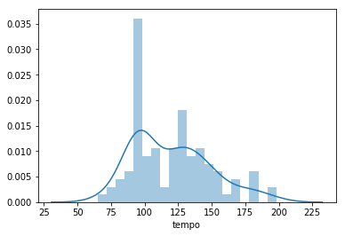

```python
sns.distplot(data['tempo'], bins=20, kde=True)
```

What is the musical tempo?

At first the musical scores did not give us indications about the tempo or they were very scarce, so each interpreter performed it at ease, but the idea of the tempo begins to change from the eighteenth and nineteenth century, possibly as a consequence of the fact that composers will be tired of listening to interpretations of their works with completely arbitrary times. Then came a notation that expressed the "speed" or form that the works should be executed.

The 5 most usual ones were:

- Length: very slow (20 bpm)
- Adagio: slow and majestic (66 to 76 bpm)
- Andante: at the pace, quiet, a little vivacious (76 to 108 bpm)
- Allegro: animated and fast. (110 to 168 bpm).
- Presto: very fast (168 to 200 bpm).

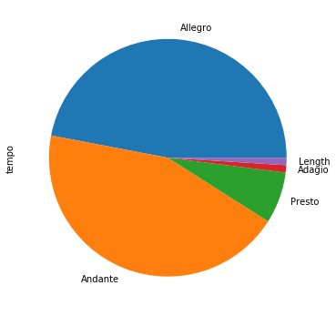

```python
pd.cut(data['tempo'],
       bins=[25, 66, 76, 108, 168, 225],
       labels=['Length', 'Adagio', 'Andante', 'Allegro', 'Presto']).value_counts().plot.pie(figsize=(6,6))
```

```python
correlations('tempo', ['key', 'mode'])
```

```
instrumentalness    0.178142
speechiness         0.102999
time_signature      0.090191
energy              0.062272
duration_ms         0.005493
Name: tempo, dtype: float64
```

**DURATION**

```python
data['duration_min'] = data['duration_ms'].apply(lambda x: x/(60*1000))
data.drop(['duration_ms'], axis=1, inplace=True)
```

```python
print('Longest Song')
data.sort_values('duration_min', ascending=False)[['name', 'duration_min']].head(1).reset_index(drop=True)
```

```
Longest Song
```

|  | name | duration_min |
| --- | --- | --- |
| 0 | Te Bot? - Remix | 6.965333 |

```python
print('Shortest Song')
data.sort_values('duration_min', ascending=True)[['name', 'duration_min']].head(1).reset_index(drop=True)
```

```
Shortest Song
```

|  | name | duration_min |
| --- | --- | --- |
| 0 | Everybody Dies In Their Nightmares | 1.591117 |

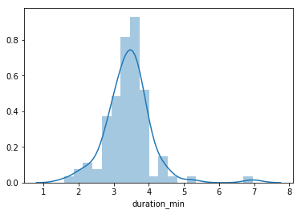

```python
sns.distplot(data['duration_min'], bins=20, kde=True)
```

```python
print(f'Most songs are generally {data["duration_min"].median():.2f} mins long')
```

```
Most songs are generally 3.42 mins long
```

```python
correlations('duration_min', ['key', 'mode'])
```

```
loudness       0.265310
energy         0.073017
tempo          0.005493
speechiness   -0.009856
liveness      -0.042942
Name: duration_min, dtype: float64
```

**TIME SIGNATURE**

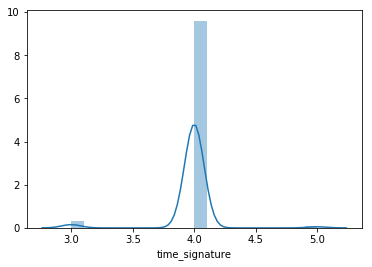

```python
sns.distplot(data['time_signature'], bins=20, kde=True)
```

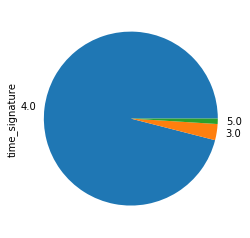

```python
data['time_signature'].value_counts().plot.pie()
```

```python
correlations('time_signature', ['key', 'mode'])
```

```
energy          0.255235
speechiness     0.235615
valence         0.223410
danceability    0.119421
tempo           0.090191
Name: time_signature, dtype: float64
```

**CORRELATION AT A GLANCE**

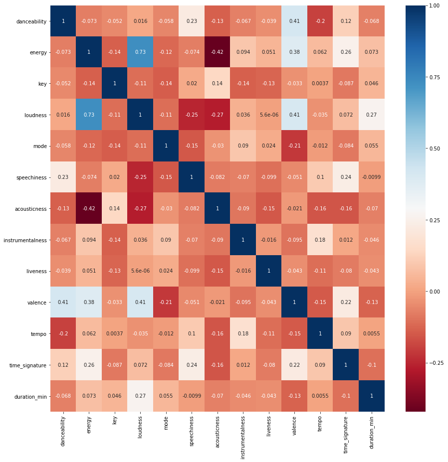

```python
fig, ax = plt.subplots(figsize=(15,15))
sns.heatmap(data.corr(),cmap="RdBu", ax=ax, annot=True)
```